# Risk Factor Analysis

## Outcome Variable

**Outcome Variable:** ever_wasted

## Predictor Variables

**Intervention Variable:** hhwealth_quart

**Adjustment Set:**

unadjusted

## Stratifying Variables

The analysis was stratified on these variable(s):

- agecat
- studyid
- country

## Data Summary

| agecat | studyid | country | hhwealth_quart | ever_wasted | n_cell | n | outcome_variable |
| --- | --- | --- | --- | --- | --- | --- | --- |
| 0-24 months | ki0047075b-MAL-ED | BANGLADESH | Wealth Q4 | 0 | 44 | 242 | ever_wasted |
| 0-24 months | ki0047075b-MAL-ED | BANGLADESH | Wealth Q4 | 1 | 17 | 242 | ever_wasted |
| 0-24 months | ki0047075b-MAL-ED | BANGLADESH | Wealth Q1 | 0 | 40 | 242 | ever_wasted |
| 0-24 months | ki0047075b-MAL-ED | BANGLADESH | Wealth Q1 | 1 | 20 | 242 | ever_wasted |
| 0-24 months | ki0047075b-MAL-ED | BANGLADESH | Wealth Q2 | 0 | 36 | 242 | ever_wasted |
| 0-24 months | ki0047075b-MAL-ED | BANGLADESH | Wealth Q2 | 1 | 25 | 242 | ever_wasted |
| 0-24 months | ki0047075b-MAL-ED | BANGLADESH | Wealth Q3 | 0 | 38 | 242 | ever_wasted |
| 0-24 months | ki0047075b-MAL-ED | BANGLADESH | Wealth Q3 | 1 | 22 | 242 | ever_wasted |
| 0-24 months | ki0047075b-MAL-ED | BRAZIL | Wealth Q4 | 0 | 44 | 210 | ever_wasted |
| 0-24 months | ki0047075b-MAL-ED | BRAZIL | Wealth Q4 | 1 | 9 | 210 | ever_wasted |
| 0-24 months | ki0047075b-MAL-ED | BRAZIL | Wealth Q1 | 0 | 48 | 210 | ever_wasted |
| 0-24 months | ki0047075b-MAL-ED | BRAZIL | Wealth Q1 | 1 | 5 | 210 | ever_wasted |
| 0-24 months | ki0047075b-MAL-ED | BRAZIL | Wealth Q2 | 0 | 50 | 210 | ever_wasted |
| 0-24 months | ki0047075b-MAL-ED | BRAZIL | Wealth Q2 | 1 | 3 | 210 | ever_wasted |
| 0-24 months | ki0047075b-MAL-ED | BRAZIL | Wealth Q3 | 0 | 48 | 210 | ever_wasted |
| 0-24 months | ki0047075b-MAL-ED | BRAZIL | Wealth Q3 | 1 | 3 | 210 | ever_wasted |
| 0-24 months | ki0047075b-MAL-ED | INDIA | Wealth Q4 | 0 | 34 | 235 | ever_wasted |
| 0-24 months | ki0047075b-MAL-ED | INDIA | Wealth Q4 | 1 | 25 | 235 | ever_wasted |
| 0-24 months | ki0047075b-MAL-ED | INDIA | Wealth Q1 | 0 | 26 | 235 | ever_wasted |
| 0-24 months | ki0047075b-MAL-ED | INDIA | Wealth Q1 | 1 | 34 | 235 | ever_wasted |
| 0-24 months | ki0047075b-MAL-ED | INDIA | Wealth Q2 | 0 | 28 | 235 | ever_wasted |
| 0-24 months | ki0047075b-MAL-ED | INDIA | Wealth Q2 | 1 | 30 | 235 | ever_wasted |
| 0-24 months | ki0047075b-MAL-ED | INDIA | Wealth Q3 | 0 | 33 | 235 | ever_wasted |
| 0-24 months | ki0047075b-MAL-ED | INDIA | Wealth Q3 | 1 | 25 | 235 | ever_wasted |
| 0-24 months | ki0047075b-MAL-ED | NEPAL | Wealth Q4 | 0 | 42 | 236 | ever_wasted |
| 0-24 months | ki0047075b-MAL-ED | NEPAL | Wealth Q4 | 1 | 17 | 236 | ever_wasted |
| 0-24 months | ki0047075b-MAL-ED | NEPAL | Wealth Q1 | 0 | 37 | 236 | ever_wasted |
| 0-24 months | ki0047075b-MAL-ED | NEPAL | Wealth Q1 | 1 | 22 | 236 | ever_wasted |
| 0-24 months | ki0047075b-MAL-ED | NEPAL | Wealth Q2 | 0 | 47 | 236 | ever_wasted |
| 0-24 months | ki0047075b-MAL-ED | NEPAL | Wealth Q2 | 1 | 12 | 236 | ever_wasted |

[output cut: 402 more lines]

The following strata were considered:

- agecat: 0-24 months, studyid: ki0047075b-MAL-ED, country: BANGLADESH
- agecat: 0-24 months, studyid: ki0047075b-MAL-ED, country: BRAZIL
- agecat: 0-24 months, studyid: ki0047075b-MAL-ED, country: INDIA
- agecat: 0-24 months, studyid: ki0047075b-MAL-ED, country: NEPAL
- agecat: 0-24 months, studyid: ki0047075b-MAL-ED, country: PERU
- agecat: 0-24 months, studyid: ki0047075b-MAL-ED, country: SOUTH AFRICA
- agecat: 0-24 months, studyid: ki0047075b-MAL-ED, country: TANZANIA, UNITED REPUBLIC OF
- agecat: 0-24 months, studyid: ki1000108-CMC-V-BCS-2002, country: INDIA
- agecat: 0-24 months, studyid: ki1000108-IRC, country: INDIA
- agecat: 0-24 months, studyid: ki1017093b-PROVIDE, country: BANGLADESH
- agecat: 0-24 months, studyid: ki1066203-TanzaniaChild2, country: TANZANIA, UNITED REPUBLIC OF
- agecat: 0-24 months, studyid: ki1113344-GMS-Nepal, country: NEPAL
- agecat: 0-24 months, studyid: ki1114097-CONTENT, country: PERU
- agecat: 0-24 months, studyid: ki1135781-COHORTS, country: GUATEMALA
- agecat: 0-24 months, studyid: ki1135781-COHORTS, country: PHILIPPINES
- agecat: 0-24 months, studyid: ki1148112-LCNI-5, country: MALAWI
- agecat: 0-24 months, studyid: kiGH5241-JiVitA-3, country: BANGLADESH
- agecat: 0-24 months, studyid: kiGH5241-JiVitA-4, country: BANGLADESH
- agecat: 0-6 months, studyid: ki0047075b-MAL-ED, country: BANGLADESH
- agecat: 0-6 months, studyid: ki0047075b-MAL-ED, country: BRAZIL
- agecat: 0-6 months, studyid: ki0047075b-MAL-ED, country: INDIA
- agecat: 0-6 months, studyid: ki0047075b-MAL-ED, country: NEPAL
- agecat: 0-6 months, studyid: ki0047075b-MAL-ED, country: PERU
- agecat: 0-6 months, studyid: ki0047075b-MAL-ED, country: SOUTH AFRICA
- agecat: 0-6 months, studyid: ki0047075b-MAL-ED, country: TANZANIA, UNITED REPUBLIC OF
- agecat: 0-6 months, studyid: ki1000108-CMC-V-BCS-2002, country: INDIA
- agecat: 0-6 months, studyid: ki1000108-IRC, country: INDIA
- agecat: 0-6 months, studyid: ki1017093b-PROVIDE, country: BANGLADESH
- agecat: 0-6 months, studyid: ki1066203-TanzaniaChild2, country: TANZANIA, UNITED REPUBLIC OF
- agecat: 0-6 months, studyid: ki1113344-GMS-Nepal, country: NEPAL
- agecat: 0-6 months, studyid: ki1114097-CONTENT, country: PERU
- agecat: 0-6 months, studyid: ki1135781-COHORTS, country: GUATEMALA
- agecat: 0-6 months, studyid: ki1135781-COHORTS, country: PHILIPPINES
- agecat: 0-6 months, studyid: ki1148112-LCNI-5, country: MALAWI
- agecat: 0-6 months, studyid: kiGH5241-JiVitA-3, country: BANGLADESH
- agecat: 0-6 months, studyid: kiGH5241-JiVitA-4, country: BANGLADESH
- agecat: 6-24 months, studyid: ki0047075b-MAL-ED, country: BANGLADESH
- agecat: 6-24 months, studyid: ki0047075b-MAL-ED, country: BRAZIL
- agecat: 6-24 months, studyid: ki0047075b-MAL-ED, country: INDIA
- agecat: 6-24 months, studyid: ki0047075b-MAL-ED, country: NEPAL
- agecat: 6-24 months, studyid: ki0047075b-MAL-ED, country: PERU
- agecat: 6-24 months, studyid: ki0047075b-MAL-ED, country: SOUTH AFRICA
- agecat: 6-24 months, studyid: ki0047075b-MAL-ED, country: TANZANIA, UNITED REPUBLIC OF
- agecat: 6-24 months, studyid: ki1000108-CMC-V-BCS-2002, country: INDIA
- agecat: 6-24 months, studyid: ki1000108-IRC, country: INDIA
- agecat: 6-24 months, studyid: ki1017093b-PROVIDE, country: BANGLADESH
- agecat: 6-24 months, studyid: ki1066203-TanzaniaChild2, country: TANZANIA, UNITED REPUBLIC OF
- agecat: 6-24 months, studyid: ki1113344-GMS-Nepal, country: NEPAL
- agecat: 6-24 months, studyid: ki1114097-CONTENT, country: PERU
- agecat: 6-24 months, studyid: ki1135781-COHORTS, country: GUATEMALA
- agecat: 6-24 months, studyid: ki1135781-COHORTS, country: PHILIPPINES
- agecat: 6-24 months, studyid: ki1148112-LCNI-5, country: MALAWI
- agecat: 6-24 months, studyid: kiGH5241-JiVitA-3, country: BANGLADESH
- agecat: 6-24 months, studyid: kiGH5241-JiVitA-4, country: BANGLADESH

### Dropped Strata

Some strata were dropped due to rare outcomes:

- agecat: 0-24 months, studyid: ki0047075b-MAL-ED, country: BRAZIL
- agecat: 0-24 months, studyid: ki1114097-CONTENT, country: PERU
- agecat: 0-6 months, studyid: ki0047075b-MAL-ED, country: BRAZIL
- agecat: 0-6 months, studyid: ki0047075b-MAL-ED, country: PERU
- agecat: 0-6 months, studyid: ki0047075b-MAL-ED, country: TANZANIA, UNITED REPUBLIC OF
- agecat: 0-6 months, studyid: ki1114097-CONTENT, country: PERU
- agecat: 0-6 months, studyid: ki1148112-LCNI-5, country: MALAWI
- agecat: 6-24 months, studyid: ki0047075b-MAL-ED, country: BRAZIL
- agecat: 6-24 months, studyid: ki0047075b-MAL-ED, country: PERU
- agecat: 6-24 months, studyid: ki0047075b-MAL-ED, country: TANZANIA, UNITED REPUBLIC OF
- agecat: 6-24 months, studyid: ki1114097-CONTENT, country: PERU

## Methods Detail

We’re interested in the causal parameters $E[Y_a]$ for all values of $a \in \mathcal{A}$. These parameters represent the mean outcome if, possibly contrary to fact, we intervened to set all units to have $A=a$. Under the randomization and positivity assumptions, these are identified by the statistical parameters $\psi_a=E_W[E_{Y|A,W}(Y|A=a,W)]$. In addition, we’re interested in the mean of $Y$, $E[Y]$ under no intervention (the observed mean). We will estimate these parameters by using SuperLearner to fit the relevant likelihood factors – $E_{Y|A,W}(Y|A=a,W)$ and $p(A=a|W)$, and then updating our likelihood fit using a joint TMLE.

For unadjusted analyses ($W=\{\}$), initial likelihoods were estimated using Lrnr_glm to estimate the simple $E(Y|A)$ and Lrnr_mean to estimate $p(A)$. For adjusted analyses, a small library containing Lrnr_glmnet, Lrnr_xgboost, and Lrnr_mean was used.

Having estimated these parameters, we will then use the delta method to estimate relative risks and attributable risks relative to a prespecified baseline level of $A$.

# Results Detail

## Results Plots

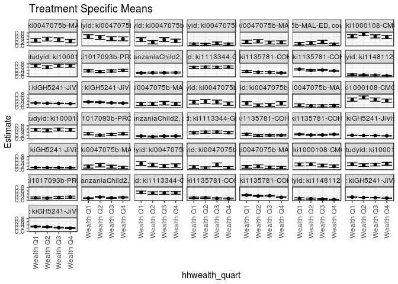

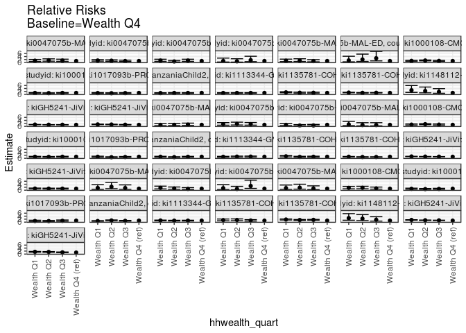

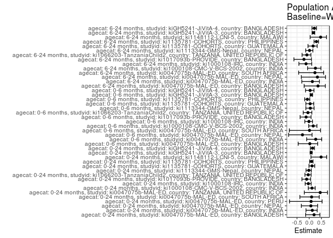

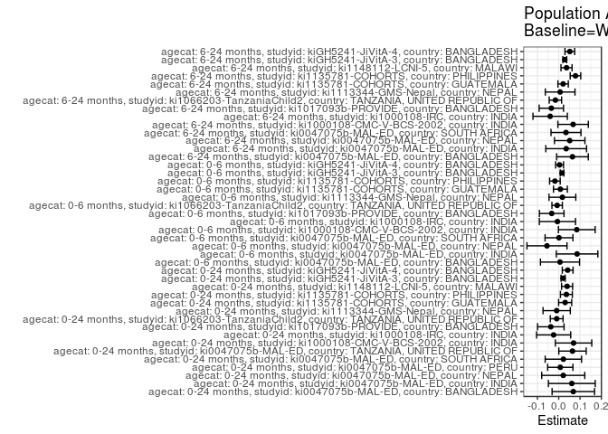

## Results Table

### Parameter: TSM

| agecat | studyid | country | intervention_level | baseline_level | estimate | ci_lower | ci_upper |
| --- | --- | --- | --- | --- | --- | --- | --- |
| 0-24 months | ki0047075b-MAL-ED | BANGLADESH | Wealth Q4 | NA | 0.2786885 | 0.1659420 | 0.3914351 |
| 0-24 months | ki0047075b-MAL-ED | BANGLADESH | Wealth Q1 | NA | 0.3333333 | 0.2138065 | 0.4528602 |
| 0-24 months | ki0047075b-MAL-ED | BANGLADESH | Wealth Q2 | NA | 0.4098361 | 0.2861634 | 0.5335087 |
| 0-24 months | ki0047075b-MAL-ED | BANGLADESH | Wealth Q3 | NA | 0.3666667 | 0.2444801 | 0.4888532 |
| 0-24 months | ki0047075b-MAL-ED | INDIA | Wealth Q4 | NA | 0.4237288 | 0.2973700 | 0.5500876 |
| 0-24 months | ki0047075b-MAL-ED | INDIA | Wealth Q1 | NA | 0.5666667 | 0.4410135 | 0.6923198 |
| 0-24 months | ki0047075b-MAL-ED | INDIA | Wealth Q2 | NA | 0.5172414 | 0.3883655 | 0.6461173 |
| 0-24 months | ki0047075b-MAL-ED | INDIA | Wealth Q3 | NA | 0.4310345 | 0.3033144 | 0.5587545 |
| 0-24 months | ki0047075b-MAL-ED | NEPAL | Wealth Q4 | NA | 0.2881356 | 0.1723269 | 0.4039443 |
| 0-24 months | ki0047075b-MAL-ED | NEPAL | Wealth Q1 | NA | 0.3728814 | 0.2492284 | 0.4965343 |
| 0-24 months | ki0047075b-MAL-ED | NEPAL | Wealth Q2 | NA | 0.2033898 | 0.1004623 | 0.3063174 |
| 0-24 months | ki0047075b-MAL-ED | NEPAL | Wealth Q3 | NA | 0.3728814 | 0.2492284 | 0.4965343 |
| 0-24 months | ki0047075b-MAL-ED | PERU | Wealth Q4 | NA | 0.0882353 | 0.0206961 | 0.1557745 |
| 0-24 months | ki0047075b-MAL-ED | PERU | Wealth Q1 | NA | 0.0882353 | 0.0206961 | 0.1557745 |
| 0-24 months | ki0047075b-MAL-ED | PERU | Wealth Q2 | NA | 0.0704225 | 0.0107991 | 0.1300460 |
| 0-24 months | ki0047075b-MAL-ED | PERU | Wealth Q3 | NA | 0.1384615 | 0.0543427 | 0.2225804 |
| 0-24 months | ki0047075b-MAL-ED | SOUTH AFRICA | Wealth Q4 | NA | 0.2000000 | 0.1025688 | 0.2974312 |
| 0-24 months | ki0047075b-MAL-ED | SOUTH AFRICA | Wealth Q1 | NA | 0.2343750 | 0.1303906 | 0.3383594 |
| 0-24 months | ki0047075b-MAL-ED | SOUTH AFRICA | Wealth Q2 | NA | 0.2656250 | 0.1572078 | 0.3740422 |
| 0-24 months | ki0047075b-MAL-ED | SOUTH AFRICA | Wealth Q3 | NA | 0.1875000 | 0.0916886 | 0.2833114 |
| 0-24 months | ki0047075b-MAL-ED | TANZANIA, UNITED REPUBLIC OF | Wealth Q4 | NA | 0.0793651 | 0.0124835 | 0.1462467 |
| 0-24 months | ki0047075b-MAL-ED | TANZANIA, UNITED REPUBLIC OF | Wealth Q1 | NA | 0.1111111 | 0.0333521 | 0.1888701 |
| 0-24 months | ki0047075b-MAL-ED | TANZANIA, UNITED REPUBLIC OF | Wealth Q2 | NA | 0.1612903 | 0.0695559 | 0.2530248 |
| 0-24 months | ki0047075b-MAL-ED | TANZANIA, UNITED REPUBLIC OF | Wealth Q3 | NA | 0.2258065 | 0.1215230 | 0.3300899 |
| 0-24 months | ki1000108-CMC-V-BCS-2002 | INDIA | Wealth Q4 | NA | 0.5416667 | 0.4418617 | 0.6414716 |
| 0-24 months | ki1000108-CMC-V-BCS-2002 | INDIA | Wealth Q1 | NA | 0.5934066 | 0.4923495 | 0.6944637 |
| 0-24 months | ki1000108-CMC-V-BCS-2002 | INDIA | Wealth Q2 | NA | 0.7263158 | 0.6365405 | 0.8160911 |
| 0-24 months | ki1000108-CMC-V-BCS-2002 | INDIA | Wealth Q3 | NA | 0.5824176 | 0.4809567 | 0.6838785 |
| 0-24 months | ki1000108-IRC | INDIA | Wealth Q4 | NA | 0.6800000 | 0.5884607 | 0.7715393 |
| 0-24 months | ki1000108-IRC | INDIA | Wealth Q1 | NA | 0.6761905 | 0.5865791 | 0.7658018 |

[output cut: 142 more lines]

### Parameter: E(Y)

| agecat | studyid | country | intervention_level | baseline_level | estimate | ci_lower | ci_upper |
| --- | --- | --- | --- | --- | --- | --- | --- |
| 0-24 months | ki0047075b-MAL-ED | BANGLADESH | NA | NA | 0.3471074 | 0.2870050 | 0.4072099 |
| 0-24 months | ki0047075b-MAL-ED | INDIA | NA | NA | 0.4851064 | 0.4210714 | 0.5491414 |
| 0-24 months | ki0047075b-MAL-ED | NEPAL | NA | NA | 0.3093220 | 0.2502261 | 0.3684179 |
| 0-24 months | ki0047075b-MAL-ED | PERU | NA | NA | 0.0955882 | 0.0605817 | 0.1305947 |
| 0-24 months | ki0047075b-MAL-ED | SOUTH AFRICA | NA | NA | 0.2217899 | 0.1708981 | 0.2726816 |
| 0-24 months | ki0047075b-MAL-ED | TANZANIA, UNITED REPUBLIC OF | NA | NA | 0.1440000 | 0.1003920 | 0.1876080 |
| 0-24 months | ki1000108-CMC-V-BCS-2002 | INDIA | NA | NA | 0.6112601 | 0.5617242 | 0.6607959 |
| 0-24 months | ki1000108-IRC | INDIA | NA | NA | 0.6560976 | 0.6100625 | 0.7021326 |
| 0-24 months | ki1017093b-PROVIDE | BANGLADESH | NA | NA | 0.3514286 | 0.3160364 | 0.3868207 |
| 0-24 months | ki1066203-TanzaniaChild2 | TANZANIA, UNITED REPUBLIC OF | NA | NA | 0.2365772 | 0.2195142 | 0.2536402 |
| 0-24 months | ki1113344-GMS-Nepal | NEPAL | NA | NA | 0.5903790 | 0.5535526 | 0.6272054 |
| 0-24 months | ki1135781-COHORTS | GUATEMALA | NA | NA | 0.2612827 | 0.2370438 | 0.2855216 |
| 0-24 months | ki1135781-COHORTS | PHILIPPINES | NA | NA | 0.4037451 | 0.3863123 | 0.4211779 |
| 0-24 months | ki1148112-LCNI-5 | MALAWI | NA | NA | 0.0807834 | 0.0620863 | 0.0994804 |
| 0-24 months | kiGH5241-JiVitA-3 | BANGLADESH | NA | NA | 0.2579831 | 0.2515145 | 0.2644516 |
| 0-24 months | kiGH5241-JiVitA-4 | BANGLADESH | NA | NA | 0.3101161 | 0.2957091 | 0.3245231 |
| 0-6 months | ki0047075b-MAL-ED | BANGLADESH | NA | NA | 0.2355372 | 0.1819640 | 0.2891104 |
| 0-6 months | ki0047075b-MAL-ED | INDIA | NA | NA | 0.3234043 | 0.2634696 | 0.3833389 |
| 0-6 months | ki0047075b-MAL-ED | NEPAL | NA | NA | 0.1991525 | 0.1480924 | 0.2502127 |
| 0-6 months | ki0047075b-MAL-ED | SOUTH AFRICA | NA | NA | 0.1089494 | 0.0707821 | 0.1471167 |
| 0-6 months | ki1000108-CMC-V-BCS-2002 | INDIA | NA | NA | 0.5163043 | 0.4651769 | 0.5674318 |
| 0-6 months | ki1000108-IRC | INDIA | NA | NA | 0.5439024 | 0.4956326 | 0.5921723 |
| 0-6 months | ki1017093b-PROVIDE | BANGLADESH | NA | NA | 0.2585714 | 0.2261125 | 0.2910304 |
| 0-6 months | ki1066203-TanzaniaChild2 | TANZANIA, UNITED REPUBLIC OF | NA | NA | 0.1392617 | 0.1253610 | 0.1531625 |
| 0-6 months | ki1113344-GMS-Nepal | NEPAL | NA | NA | 0.3760933 | 0.3398180 | 0.4123685 |
| 0-6 months | ki1135781-COHORTS | GUATEMALA | NA | NA | 0.2029557 | 0.1782002 | 0.2277111 |
| 0-6 months | ki1135781-COHORTS | PHILIPPINES | NA | NA | 0.2356227 | 0.2205417 | 0.2507038 |
| 0-6 months | kiGH5241-JiVitA-3 | BANGLADESH | NA | NA | 0.1761878 | 0.1705589 | 0.1818167 |
| 0-6 months | kiGH5241-JiVitA-4 | BANGLADESH | NA | NA | 0.1078103 | 0.0979895 | 0.1176312 |
| 6-24 months | ki0047075b-MAL-ED | BANGLADESH | NA | NA | 0.1791667 | 0.1305478 | 0.2277856 |
| 6-24 months | ki0047075b-MAL-ED | INDIA | NA | NA | 0.2723404 | 0.2153029 | 0.3293779 |
| 6-24 months | ki0047075b-MAL-ED | NEPAL | NA | NA | 0.1531915 | 0.1070438 | 0.1993392 |
| 6-24 months | ki0047075b-MAL-ED | SOUTH AFRICA | NA | NA | 0.1450980 | 0.1017849 | 0.1884112 |
| 6-24 months | ki1000108-CMC-V-BCS-2002 | INDIA | NA | NA | 0.2654155 | 0.2205451 | 0.3102860 |
| 6-24 months | ki1000108-IRC | INDIA | NA | NA | 0.3097561 | 0.2649438 | 0.3545684 |
| 6-24 months | ki1017093b-PROVIDE | BANGLADESH | NA | NA | 0.1609756 | 0.1319065 | 0.1900447 |
| 6-24 months | ki1066203-TanzaniaChild2 | TANZANIA, UNITED REPUBLIC OF | NA | NA | 0.1606965 | 0.1446374 | 0.1767556 |
| 6-24 months | ki1113344-GMS-Nepal | NEPAL | NA | NA | 0.4728814 | 0.4325613 | 0.5132014 |
| 6-24 months | ki1135781-COHORTS | GUATEMALA | NA | NA | 0.1291161 | 0.1097606 | 0.1484716 |
| 6-24 months | ki1135781-COHORTS | PHILIPPINES | NA | NA | 0.2666429 | 0.2502871 | 0.2829988 |
| 6-24 months | ki1148112-LCNI-5 | MALAWI | NA | NA | 0.0782609 | 0.0596958 | 0.0968259 |
| 6-24 months | kiGH5241-JiVitA-3 | BANGLADESH | NA | NA | 0.1638036 | 0.1576801 | 0.1699271 |
| 6-24 months | kiGH5241-JiVitA-4 | BANGLADESH | NA | NA | 0.2472801 | 0.2337480 | 0.2608122 |

### Parameter: RR

| agecat | studyid | country | intervention_level | baseline_level | estimate | ci_lower | ci_upper |
| --- | --- | --- | --- | --- | --- | --- | --- |
| 0-24 months | ki0047075b-MAL-ED | BANGLADESH | Wealth Q4 | Wealth Q4 | 1.0000000 | 1.0000000 | 1.0000000 |
| 0-24 months | ki0047075b-MAL-ED | BANGLADESH | Wealth Q1 | Wealth Q4 | 1.1960784 | 0.6965937 | 2.0537132 |
| 0-24 months | ki0047075b-MAL-ED | BANGLADESH | Wealth Q2 | Wealth Q4 | 1.4705882 | 0.8877678 | 2.4360307 |
| 0-24 months | ki0047075b-MAL-ED | BANGLADESH | Wealth Q3 | Wealth Q4 | 1.3156863 | 0.7789759 | 2.2221875 |
| 0-24 months | ki0047075b-MAL-ED | INDIA | Wealth Q4 | Wealth Q4 | 1.0000000 | 1.0000000 | 1.0000000 |
| 0-24 months | ki0047075b-MAL-ED | INDIA | Wealth Q1 | Wealth Q4 | 1.3373333 | 0.9222532 | 1.9392294 |
| 0-24 months | ki0047075b-MAL-ED | INDIA | Wealth Q2 | Wealth Q4 | 1.2206897 | 0.8276362 | 1.8004084 |
| 0-24 months | ki0047075b-MAL-ED | INDIA | Wealth Q3 | Wealth Q4 | 1.0172414 | 0.6681150 | 1.5488052 |
| 0-24 months | ki0047075b-MAL-ED | NEPAL | Wealth Q4 | Wealth Q4 | 1.0000000 | 1.0000000 | 1.0000000 |
| 0-24 months | ki0047075b-MAL-ED | NEPAL | Wealth Q1 | Wealth Q4 | 1.2941176 | 0.7685586 | 2.1790668 |
| 0-24 months | ki0047075b-MAL-ED | NEPAL | Wealth Q2 | Wealth Q4 | 0.7058824 | 0.3698870 | 1.3470869 |
| 0-24 months | ki0047075b-MAL-ED | NEPAL | Wealth Q3 | Wealth Q4 | 1.2941176 | 0.7685586 | 2.1790668 |
| 0-24 months | ki0047075b-MAL-ED | PERU | Wealth Q4 | Wealth Q4 | 1.0000000 | 1.0000000 | 1.0000000 |
| 0-24 months | ki0047075b-MAL-ED | PERU | Wealth Q1 | Wealth Q4 | 1.0000000 | 0.3387470 | 2.9520560 |
| 0-24 months | ki0047075b-MAL-ED | PERU | Wealth Q2 | Wealth Q4 | 0.7981221 | 0.2549050 | 2.4989660 |
| 0-24 months | ki0047075b-MAL-ED | PERU | Wealth Q3 | Wealth Q4 | 1.5692308 | 0.5905794 | 4.1696087 |
| 0-24 months | ki0047075b-MAL-ED | SOUTH AFRICA | Wealth Q4 | Wealth Q4 | 1.0000000 | 1.0000000 | 1.0000000 |
| 0-24 months | ki0047075b-MAL-ED | SOUTH AFRICA | Wealth Q1 | Wealth Q4 | 1.1718750 | 0.6063462 | 2.2648628 |
| 0-24 months | ki0047075b-MAL-ED | SOUTH AFRICA | Wealth Q2 | Wealth Q4 | 1.3281250 | 0.7034387 | 2.5075617 |
| 0-24 months | ki0047075b-MAL-ED | SOUTH AFRICA | Wealth Q3 | Wealth Q4 | 0.9375000 | 0.4627639 | 1.8992541 |
| 0-24 months | ki0047075b-MAL-ED | TANZANIA, UNITED REPUBLIC OF | Wealth Q4 | Wealth Q4 | 1.0000000 | 1.0000000 | 1.0000000 |
| 0-24 months | ki0047075b-MAL-ED | TANZANIA, UNITED REPUBLIC OF | Wealth Q1 | Wealth Q4 | 1.4000000 | 0.4681641 | 4.1865664 |
| 0-24 months | ki0047075b-MAL-ED | TANZANIA, UNITED REPUBLIC OF | Wealth Q2 | Wealth Q4 | 2.0322581 | 0.7352592 | 5.6171658 |
| 0-24 months | ki0047075b-MAL-ED | TANZANIA, UNITED REPUBLIC OF | Wealth Q3 | Wealth Q4 | 2.8451613 | 1.0883485 | 7.4378221 |
| 0-24 months | ki1000108-CMC-V-BCS-2002 | INDIA | Wealth Q4 | Wealth Q4 | 1.0000000 | 1.0000000 | 1.0000000 |
| 0-24 months | ki1000108-CMC-V-BCS-2002 | INDIA | Wealth Q1 | Wealth Q4 | 1.0955199 | 0.8524220 | 1.4079455 |
| 0-24 months | ki1000108-CMC-V-BCS-2002 | INDIA | Wealth Q2 | Wealth Q4 | 1.3408907 | 1.0740757 | 1.6739861 |
| 0-24 months | ki1000108-CMC-V-BCS-2002 | INDIA | Wealth Q3 | Wealth Q4 | 1.0752325 | 0.8344074 | 1.3855639 |
| 0-24 months | ki1000108-IRC | INDIA | Wealth Q4 | Wealth Q4 | 1.0000000 | 1.0000000 | 1.0000000 |
| 0-24 months | ki1000108-IRC | INDIA | Wealth Q1 | Wealth Q4 | 0.9943978 | 0.8232292 | 1.2011563 |

[output cut: 142 more lines]

### Parameter: PAR

| agecat | studyid | country | intervention_level | baseline_level | estimate | ci_lower | ci_upper |
| --- | --- | --- | --- | --- | --- | --- | --- |
| 0-24 months | ki0047075b-MAL-ED | BANGLADESH | Wealth Q4 | NA | 0.0684189 | -0.0311586 | 0.1679964 |
| 0-24 months | ki0047075b-MAL-ED | INDIA | Wealth Q4 | NA | 0.0613776 | -0.0483939 | 0.1711491 |
| 0-24 months | ki0047075b-MAL-ED | NEPAL | Wealth Q4 | NA | 0.0211864 | -0.0797995 | 0.1221724 |
| 0-24 months | ki0047075b-MAL-ED | PERU | Wealth Q4 | NA | 0.0073529 | -0.0518605 | 0.0665664 |
| 0-24 months | ki0047075b-MAL-ED | SOUTH AFRICA | Wealth Q4 | NA | 0.0217899 | -0.0635388 | 0.1071186 |
| 0-24 months | ki0047075b-MAL-ED | TANZANIA, UNITED REPUBLIC OF | Wealth Q4 | NA | 0.0646349 | 0.0004450 | 0.1288248 |
| 0-24 months | ki1000108-CMC-V-BCS-2002 | INDIA | Wealth Q4 | NA | 0.0695934 | -0.0157731 | 0.1549599 |
| 0-24 months | ki1000108-IRC | INDIA | Wealth Q4 | NA | -0.0239024 | -0.1039720 | 0.0561671 |
| 0-24 months | ki1017093b-PROVIDE | BANGLADESH | Wealth Q4 | NA | -0.0371429 | -0.0993036 | 0.0250179 |
| 0-24 months | ki1066203-TanzaniaChild2 | TANZANIA, UNITED REPUBLIC OF | Wealth Q4 | NA | -0.0096286 | -0.0395542 | 0.0202971 |
| 0-24 months | ki1113344-GMS-Nepal | NEPAL | Wealth Q4 | NA | -0.0096210 | -0.0736172 | 0.0543752 |
| 0-24 months | ki1135781-COHORTS | GUATEMALA | Wealth Q4 | NA | 0.0301902 | -0.0004840 | 0.0608645 |
| 0-24 months | ki1135781-COHORTS | PHILIPPINES | Wealth Q4 | NA | 0.0358879 | 0.0079491 | 0.0638268 |
| 0-24 months | ki1148112-LCNI-5 | MALAWI | Wealth Q4 | NA | 0.0393087 | 0.0132339 | 0.0653835 |
| 0-24 months | kiGH5241-JiVitA-3 | BANGLADESH | Wealth Q4 | NA | 0.0204690 | 0.0108570 | 0.0300811 |
| 0-24 months | kiGH5241-JiVitA-4 | BANGLADESH | Wealth Q4 | NA | 0.0419679 | 0.0166936 | 0.0672423 |
| 0-6 months | ki0047075b-MAL-ED | BANGLADESH | Wealth Q4 | NA | 0.0060290 | -0.0857045 | 0.0977624 |
| 0-6 months | ki0047075b-MAL-ED | INDIA | Wealth Q4 | NA | 0.0861161 | -0.0112697 | 0.1835019 |
| 0-6 months | ki0047075b-MAL-ED | NEPAL | Wealth Q4 | NA | -0.0550847 | -0.1489240 | 0.0387545 |
| 0-6 months | ki0047075b-MAL-ED | SOUTH AFRICA | Wealth Q4 | NA | 0.0012571 | -0.0641197 | 0.0666339 |
| 0-6 months | ki1000108-CMC-V-BCS-2002 | INDIA | Wealth Q4 | NA | 0.0847254 | -0.0014445 | 0.1708953 |
| 0-6 months | ki1000108-IRC | INDIA | Wealth Q4 | NA | -0.0060976 | -0.0910189 | 0.0788238 |
| 0-6 months | ki1017093b-PROVIDE | BANGLADESH | Wealth Q4 | NA | -0.0328571 | -0.0905049 | 0.0247906 |
| 0-6 months | ki1066203-TanzaniaChild2 | TANZANIA, UNITED REPUBLIC OF | Wealth Q4 | NA | -0.0074499 | -0.0319637 | 0.0170639 |
| 0-6 months | ki1113344-GMS-Nepal | NEPAL | Wealth Q4 | NA | 0.0172698 | -0.0455146 | 0.0800541 |
| 0-6 months | ki1135781-COHORTS | GUATEMALA | Wealth Q4 | NA | 0.0078337 | -0.0247157 | 0.0403831 |
| 0-6 months | ki1135781-COHORTS | PHILIPPINES | Wealth Q4 | NA | -0.0179487 | -0.0427533 | 0.0068559 |
| 0-6 months | kiGH5241-JiVitA-3 | BANGLADESH | Wealth Q4 | NA | 0.0156018 | 0.0069729 | 0.0242307 |
| 0-6 months | kiGH5241-JiVitA-4 | BANGLADESH | Wealth Q4 | NA | 0.0039551 | -0.0145395 | 0.0224497 |
| 6-24 months | ki0047075b-MAL-ED | BANGLADESH | Wealth Q4 | NA | 0.0644126 | -0.0098997 | 0.1387248 |
| 6-24 months | ki0047075b-MAL-ED | INDIA | Wealth Q4 | NA | 0.0350523 | -0.0605778 | 0.1306824 |
| 6-24 months | ki0047075b-MAL-ED | NEPAL | Wealth Q4 | NA | 0.0514966 | -0.0199428 | 0.1229360 |
| 6-24 months | ki0047075b-MAL-ED | SOUTH AFRICA | Wealth Q4 | NA | 0.0339869 | -0.0362597 | 0.1042336 |
| 6-24 months | ki1000108-CMC-V-BCS-2002 | INDIA | Wealth Q4 | NA | 0.0674989 | -0.0039441 | 0.1389419 |
| 6-24 months | ki1000108-IRC | INDIA | Wealth Q4 | NA | -0.0402439 | -0.1208375 | 0.0403497 |
| 6-24 months | ki1017093b-PROVIDE | BANGLADESH | Wealth Q4 | NA | -0.0346766 | -0.0918052 | 0.0224521 |
| 6-24 months | ki1066203-TanzaniaChild2 | TANZANIA, UNITED REPUBLIC OF | Wealth Q4 | NA | -0.0155330 | -0.0446202 | 0.0135542 |
| 6-24 months | ki1113344-GMS-Nepal | NEPAL | Wealth Q4 | NA | 0.0066651 | -0.0629760 | 0.0763062 |
| 6-24 months | ki1135781-COHORTS | GUATEMALA | Wealth Q4 | NA | 0.0205711 | -0.0036995 | 0.0448417 |
| 6-24 months | ki1135781-COHORTS | PHILIPPINES | Wealth Q4 | NA | 0.0785755 | 0.0538612 | 0.1032898 |
| 6-24 months | ki1148112-LCNI-5 | MALAWI | Wealth Q4 | NA | 0.0365942 | 0.0106304 | 0.0625580 |
| 6-24 months | kiGH5241-JiVitA-3 | BANGLADESH | Wealth Q4 | NA | 0.0283889 | 0.0194101 | 0.0373677 |
| 6-24 months | kiGH5241-JiVitA-4 | BANGLADESH | Wealth Q4 | NA | 0.0520314 | 0.0292662 | 0.0747966 |

### Parameter: PAF

| agecat | studyid | country | intervention_level | baseline_level | estimate | ci_lower | ci_upper |
| --- | --- | --- | --- | --- | --- | --- | --- |
| 0-24 months | ki0047075b-MAL-ED | BANGLADESH | Wealth Q4 | NA | 0.1971116 | -0.1472843 | 0.4381256 |
| 0-24 months | ki0047075b-MAL-ED | INDIA | Wealth Q4 | NA | 0.1265239 | -0.1322894 | 0.3261789 |
| 0-24 months | ki0047075b-MAL-ED | NEPAL | Wealth Q4 | NA | 0.0684932 | -0.3224448 | 0.3438630 |
| 0-24 months | ki0047075b-MAL-ED | PERU | Wealth Q4 | NA | 0.0769231 | -0.8048615 | 0.5279023 |
| 0-24 months | ki0047075b-MAL-ED | SOUTH AFRICA | Wealth Q4 | NA | 0.0982456 | -0.3810916 | 0.4112186 |
| 0-24 months | ki0047075b-MAL-ED | TANZANIA, UNITED REPUBLIC OF | Wealth Q4 | NA | 0.4488536 | -0.1993803 | 0.7467339 |
| 0-24 months | ki1000108-CMC-V-BCS-2002 | INDIA | Wealth Q4 | NA | 0.1138523 | -0.0380472 | 0.2435241 |
| 0-24 months | ki1000108-IRC | INDIA | Wealth Q4 | NA | -0.0364312 | -0.1660348 | 0.0787671 |
| 0-24 months | ki1017093b-PROVIDE | BANGLADESH | Wealth Q4 | NA | -0.1056911 | -0.2975793 | 0.0578204 |
| 0-24 months | ki1066203-TanzaniaChild2 | TANZANIA, UNITED REPUBLIC OF | Wealth Q4 | NA | -0.0406994 | -0.1751888 | 0.0783990 |
| 0-24 months | ki1113344-GMS-Nepal | NEPAL | Wealth Q4 | NA | -0.0162963 | -0.1306971 | 0.0865297 |
| 0-24 months | ki1135781-COHORTS | GUATEMALA | Wealth Q4 | NA | 0.1155462 | -0.0097913 | 0.2253265 |
| 0-24 months | ki1135781-COHORTS | PHILIPPINES | Wealth Q4 | NA | 0.0888876 | 0.0169659 | 0.1555473 |
| 0-24 months | ki1148112-LCNI-5 | MALAWI | Wealth Q4 | NA | 0.4865940 | 0.0711724 | 0.7162168 |
| 0-24 months | kiGH5241-JiVitA-3 | BANGLADESH | Wealth Q4 | NA | 0.0793426 | 0.0412250 | 0.1159447 |
| 0-24 months | kiGH5241-JiVitA-4 | BANGLADESH | Wealth Q4 | NA | 0.1353298 | 0.0496204 | 0.2133095 |
| 0-6 months | ki0047075b-MAL-ED | BANGLADESH | Wealth Q4 | NA | 0.0255968 | -0.4531706 | 0.3466276 |
| 0-6 months | ki0047075b-MAL-ED | INDIA | Wealth Q4 | NA | 0.2662801 | -0.1042152 | 0.5124638 |
| 0-6 months | ki0047075b-MAL-ED | NEPAL | Wealth Q4 | NA | -0.2765957 | -0.8436894 | 0.1160677 |
| 0-6 months | ki0047075b-MAL-ED | SOUTH AFRICA | Wealth Q4 | NA | 0.0115385 | -0.8138550 | 0.4613372 |
| 0-6 months | ki1000108-CMC-V-BCS-2002 | INDIA | Wealth Q4 | NA | 0.1640997 | -0.0213825 | 0.3158985 |
| 0-6 months | ki1000108-IRC | INDIA | Wealth Q4 | NA | -0.0112108 | -0.1800482 | 0.1334699 |
| 0-6 months | ki1017093b-PROVIDE | BANGLADESH | Wealth Q4 | NA | -0.1270718 | -0.3734497 | 0.0751092 |
| 0-6 months | ki1066203-TanzaniaChild2 | TANZANIA, UNITED REPUBLIC OF | Wealth Q4 | NA | -0.0534956 | -0.2450195 | 0.1085658 |
| 0-6 months | ki1113344-GMS-Nepal | NEPAL | Wealth Q4 | NA | 0.0459188 | -0.1365251 | 0.1990754 |
| 0-6 months | ki1135781-COHORTS | GUATEMALA | Wealth Q4 | NA | 0.0385982 | -0.1358896 | 0.1862823 |
| 0-6 months | ki1135781-COHORTS | PHILIPPINES | Wealth Q4 | NA | -0.0761755 | -0.1867271 | 0.0240775 |
| 0-6 months | kiGH5241-JiVitA-3 | BANGLADESH | Wealth Q4 | NA | 0.0885522 | 0.0381987 | 0.1362695 |
| 0-6 months | kiGH5241-JiVitA-4 | BANGLADESH | Wealth Q4 | NA | 0.0366859 | -0.1514887 | 0.1941092 |
| 6-24 months | ki0047075b-MAL-ED | BANGLADESH | Wealth Q4 | NA | 0.3595120 | -0.2080619 | 0.6604273 |
| 6-24 months | ki0047075b-MAL-ED | INDIA | Wealth Q4 | NA | 0.1287076 | -0.3031984 | 0.4174714 |
| 6-24 months | ki0047075b-MAL-ED | NEPAL | Wealth Q4 | NA | 0.3361582 | -0.3232314 | 0.6669623 |
| 6-24 months | ki0047075b-MAL-ED | SOUTH AFRICA | Wealth Q4 | NA | 0.2342342 | -0.4339632 | 0.5910654 |
| 6-24 months | ki1000108-CMC-V-BCS-2002 | INDIA | Wealth Q4 | NA | 0.2543140 | -0.0675804 | 0.4791515 |
| 6-24 months | ki1000108-IRC | INDIA | Wealth Q4 | NA | -0.1299213 | -0.4225113 | 0.1024872 |
| 6-24 months | ki1017093b-PROVIDE | BANGLADESH | Wealth Q4 | NA | -0.2154150 | -0.6260260 | 0.0915067 |
| 6-24 months | ki1066203-TanzaniaChild2 | TANZANIA, UNITED REPUBLIC OF | Wealth Q4 | NA | -0.0966604 | -0.2932855 | 0.0700707 |
| 6-24 months | ki1113344-GMS-Nepal | NEPAL | Wealth Q4 | NA | 0.0140947 | -0.1447473 | 0.1508963 |
| 6-24 months | ki1135781-COHORTS | GUATEMALA | Wealth Q4 | NA | 0.1593223 | -0.0498983 | 0.3268501 |
| 6-24 months | ki1135781-COHORTS | PHILIPPINES | Wealth Q4 | NA | 0.2946843 | 0.1966146 | 0.3807826 |
| 6-24 months | ki1148112-LCNI-5 | MALAWI | Wealth Q4 | NA | 0.4675926 | 0.0389644 | 0.7050498 |
| 6-24 months | kiGH5241-JiVitA-3 | BANGLADESH | Wealth Q4 | NA | 0.1733109 | 0.1168850 | 0.2261314 |
| 6-24 months | kiGH5241-JiVitA-4 | BANGLADESH | Wealth Q4 | NA | 0.2104148 | 0.1128414 | 0.2972568 |